# modelplotr: Gain & Lift

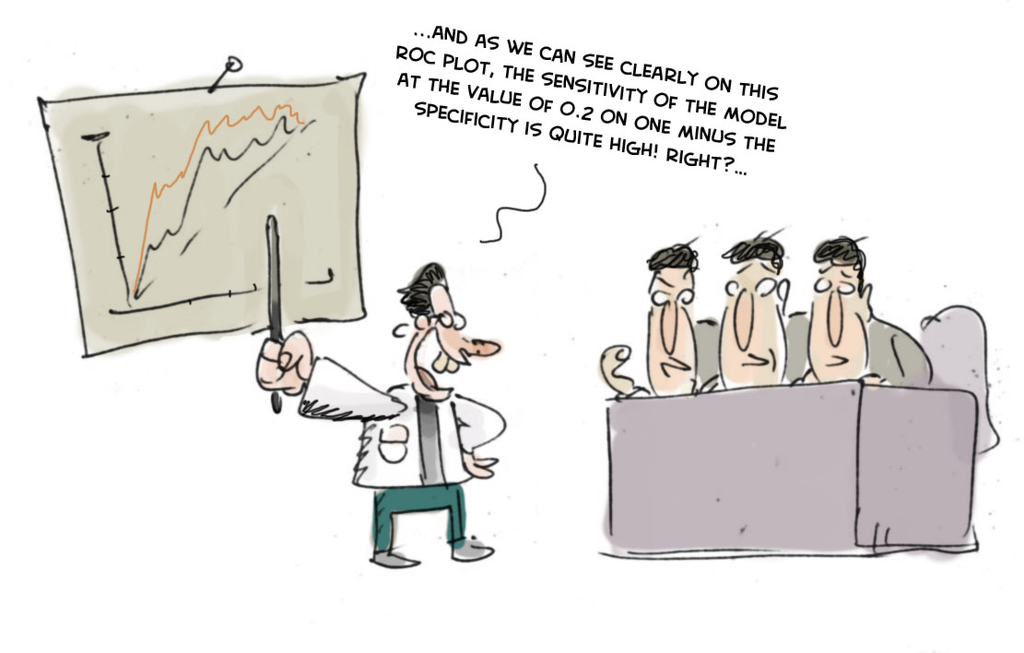

# Introduction

See https://modelplot.github.io/modelplotr.html

This document attempts to explain four most valuable evaluation plots to assess the business value of a predictive model. These plots are the cumulative gains, cumulative lift, response and cumulative response. Since these visualisations are not included in most popular model building packages, this document demonstrates how easy it is to create these plots using `modelplotr`. This will help you to explain the model’s business value in business terms to your project sponsor.

During model building efforts, the focus is on verifying how well the model performs. This is often by training the model parameters on a selection or subset of records and test the performance on a holdout set or external validation set. Performance measures like the ROC curve and the AUC value are evaluated. These plots and statistics are very helpful to check during model building and optimization whether the model is under- or overfitting and what set of parameters performs best on test data. However, these statistics are not that valuable in assessing the business value the model developed.

One reason that the ROC curve is not that useful in explaining the business value of your model is because it’s quite hard to explain the interpretation of *area under the curve*, *specificity* or *sensitivity* to business people. Another important reason that these statistics and plots are useless in your business meetings is that they don’t help in determining how to apply your predictive model: *What percentage of records should we select based on the model? Should we select only the best 10% of cases? Or should we stop at 30%? Or go on until we have selected 70%?…* This is something you want to decide together with your business colleague to best match the business plans and campaign targets they have to meet. The four plots - the cumulative gains, cumulative lift, response and cumulative response are effective ones for that cause.

# Predictive models from caret and mlr

This example is based on a publicly available dataset, the [Bank Marketing Data Set](https://archive.ics.uci.edu/ml/datasets/Bank%2BMarketing. The data set comes from a Portugese bank and deals with a frequently-posed marketing question: *whether a customer did or did not acquire a term deposit, a financial product*.

> There are 4 datasets available and the bank-additional-full.csv is the one we use. It contains the information of 41.188 customers and 21 columns of information.

## Get Data

```r
zipname = 'https://archive.ics.uci.edu/ml/machine-learning-databases/00222/bank-additional.zip'
# we encountered that the source at uci.edu is not always available, therefore we made a copy to our repos.
#zipname = 'https://modelplot.github.io/img/bank-additional.zip'
csvname = 'bank-additional/bank-additional-full.csv'
temp <- tempfile()
download.file(zipname, temp, mode="wb")
bank <- read.table(unzip(temp, csvname), sep = ";", stringsAsFactors = FALSE, header = T)
unlink(temp)

bank <- bank %>% select(y, duration, campaign, pdays, previous, euribor3m)
bank <- bank %>% mutate(y = ifelse(y == "yes", "term.deposit", y))

#explore data
str(bank)
```

```
## 'data.frame':    41188 obs. of  6 variables:
##  $ y        : chr  "no" "no" "no" "no" ...
##  $ duration : int  261 149 226 151 307 198 139 217 380 50 ...
##  $ campaign : int  1 1 1 1 1 1 1 1 1 1 ...
##  $ pdays    : int  999 999 999 999 999 999 999 999 999 999 ...
##  $ previous : int  0 0 0 0 0 0 0 0 0 0 ...
##  $ euribor3m: num  4.86 4.86 4.86 4.86 4.86 ...
```

Marketing colleagues have asked to help to select the customers that are most likely to respond to a term deposit offer. For that purpose, develop a predictive model and create the plots to discuss the results with our marketing colleagues.

For this demo, only 6 features will be selected (feel free to include more in yours to potentially create a higher perfprming model).

1. y: has the client subscribed a term deposit?
2. duration: last contact duration, in seconds (numeric)
3. campaign: number of contacts performed during this campaign and for this client
4. pdays: number of days that passed by after the client was last contacted from a previous campaign
5. previous: number of contacts performed before this campaign and for this client (numeric)
6. euribor3m: euribor 3 month rate

`mlr` and `caret` provide many algorithms for binary classification.

> To use `modelplotr`, you do not have to use `caret` or `mlr` to build your models.

## Prepare Data

```r
test_size = 0.3
train_index =  sample(seq(1, nrow(bank)),size = (1 - test_size)*nrow(bank) ,replace = F)
train = bank[train_index,]
test = bank[-train_index,]

train_index <- createDataPartition(bank$y, 0.7, list = FALSE, times=1)
train = bank[train_index,]
test = bank[-train_index,]
```

## Make Models

```r
# estimate some models with caret...
# setting caret cross validation, here tuned for speed (not accuracy!)
fitControl <- caret::trainControl(method = "cv", number = 2, classProbs=TRUE)

# mnl model using glmnet package
mnl = caret::train(y ~., data = train, method = "glmnet", trControl = fitControl)

# random forest using ranger package, here tuned for speed (not accuracy!)
rf = caret::train(y ~., data = train, method = "ranger", trControl = fitControl,
  tuneGrid = expand.grid(.mtry = 2, .splitrule = "gini", .min.node.size=10))

# ... and estimate some models with mlr
mlr::configureMlr() # this line is needed when using mlr without loading it (mlr::)
task = mlr::makeClassifTask(data = train, target = "y")

# discriminant model
lrn = mlr::makeLearner("classif.lda", predict.type = "prob")
lda = mlr::train(lrn, task)

#xgboost model
lrn = mlr::makeLearner("classif.xgboost", predict.type = "prob")
xgb = mlr::train(lrn, task)
```

## Prepare the data for plotting

Below, in the `prepare_scores_and_decil`es function, the customers are scored in the train dataset and test dataset with their probability to acquire a term deposit, according to the predictive models just built with `caret` and `mlr`. Aside from the datasets and model objects, the name of the target variable was specified.

In the second step, the scope of the analysis is specified. The “scope” parameter was not specified so the default - no comparison - is chosen. As the output notes, you can use modelplotr to evaluate your model(s) from several perspectives:

- Interpret just one model (the default)
- Compare the model performance across different datasets
- Compare the performance across different models
- Compare the performance across different target classes

Keep it simple - how well a selected model will perform in a selected dataset for one target class. Specified values for some parameters, to focus on the XGBoost model on the test data. The default value for the target class is term deposit ; since we want to focus on customers that do take term deposits, this default is perfect.

```r
# transform datasets and model objects into scored data and calculate deciles
prepare_scores_and_deciles(datasets=list("train","test"),
  dataset_labels = list("train data","test data"),
  models = list("rf","mnl","xgb","lda"),
  model_labels = list("random forest","multinomial logit","XGBoost","Discriminant"),
  target_column="y")
```

```
## ... scoring caret model "rf" on dataset "train".
## ... scoring caret model "mnl" on dataset "train".
## ... scoring mlr model "xgb" on dataset "train".
## ... scoring mlr model "lda" on dataset "train".
## ... scoring caret model "rf" on dataset "test".
## ... scoring caret model "mnl" on dataset "test".
## ... scoring mlr model "xgb" on dataset "test".
## ... scoring mlr model "lda" on dataset "test".
```

```
## [1] "Data preparation step 1 succeeded! Dataframe 'scores_and_deciles' created."
```

```r
# transform data generated with prepare_scores_and_deciles into aggregated data for chosen plotting scope
plotting_scope(select_model_label = 'XGBoost', select_dataset_label = 'test data')
```

```
## [1] "deciles_aggregate not available; input_modelevalplots() is run..."
## Data preparation step 3 succeeded! Dataframe 'plot_input' created.
##
## No comparison specified, default values are used.
##
## Single evaluation line will be plotted: Target value "term.deposit" plotted for dataset "test data" and model "XGBoost.
## "
## -> To compare models, specify: scope = "compare_models"
## -> To compare datasets, specify: scope = "compare_datasets"
## -> To compare target classes, specify: scope = "compare_targetclasses"
## -> To plot one line, do not specify scope or specify scope = "no_comparison".
```

# Gains, Lift and Cumulative Response plots

All the plots explored below all use the same data:

- Predicted probability for the target class
- Equally sized groups based on this predicted probability
- Actual number of observed target class observations in these groups

It’s common practice to split the data to score into 10 equally large groups and call these groups deciles. Observations that belong to the top-10% with highest model probability in a set, are in decile 1 of that set; the next group of 10% with high model probability are decile 2 and finally the 10% observations with the lowest model probability on the target class belong to decile 10.

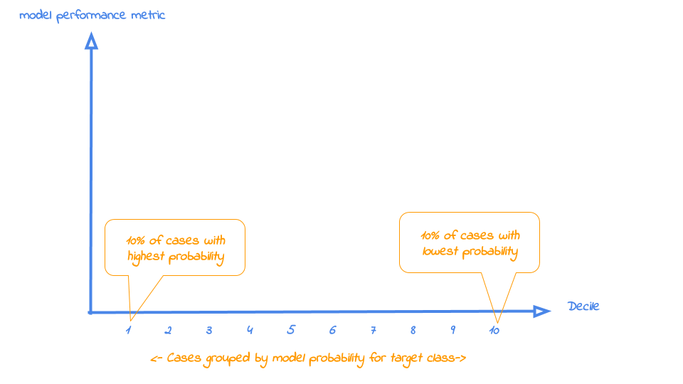

It’s clear what is on the horizontal axis of each of the plots, we can go into more detail on the metrics for each plot on the vertical axis. For each plot, we’ll start with a brief explanation what insight you gain with the plot from a business perspective. After that, we apply it to our banking data and show some neat features of modelplotr to help you explain the value of your wonderful predictive models to others.